# Part I - Prosper loan data Analysis

## Introduction

> This is a financial dataset that contains 113,937 loans with 81 variables on each loan, including loan amount, borrower rate (or interest rate), current loan status, borrower income, and many others.

## Preliminary Wrangling

```python
# import all packages and set plots to be embedded inline
import numpy as np
import pandas as pd
import matplotlib.pyplot as plt
import seaborn as sb

%matplotlib inline
import warnings
warnings.simplefilter("ignore")
```

> Load in your dataset and describe its properties through the questions below. Try and motivate your exploration goals through this section.

```python
#load the dataset and preview a sample
loan_data = pd.read_csv('prosperLoanData.csv')
loan_data.head()
```

|  | ListingKey | ListingNumber | ListingCreationDate | CreditGrade | Term | LoanStatus | ClosedDate | BorrowerAPR | BorrowerRate | LenderYield | ... | LP_ServiceFees | LP_CollectionFees | LP_GrossPrincipalLoss | LP_NetPrincipalLoss | LP_NonPrincipalRecoverypayments | PercentFunded | Recommendations | InvestmentFromFriendsCount | InvestmentFromFriendsAmount | Investors |
| --- | --- | --- | --- | --- | --- | --- | --- | --- | --- | --- | --- | --- | --- | --- | --- | --- | --- | --- | --- | --- | --- |
| 0 | 1021339766868145413AB3B | 193129 | 2007-08-26 19:09:29.263000000 | C | 36 | Completed | 2009-08-14 00:00:00 | 0.16516 | 0.1580 | 0.1380 | ... | -133.18 | 0.0 | 0.0 | 0.0 | 0.0 | 1.0 | 0 | 0 | 0.0 | 258 |
| 1 | 10273602499503308B223C1 | 1209647 | 2014-02-27 08:28:07.900000000 | NaN | 36 | Current | NaN | 0.12016 | 0.0920 | 0.0820 | ... | 0.00 | 0.0 | 0.0 | 0.0 | 0.0 | 1.0 | 0 | 0 | 0.0 | 1 |
| 2 | 0EE9337825851032864889A | 81716 | 2007-01-05 15:00:47.090000000 | HR | 36 | Completed | 2009-12-17 00:00:00 | 0.28269 | 0.2750 | 0.2400 | ... | -24.20 | 0.0 | 0.0 | 0.0 | 0.0 | 1.0 | 0 | 0 | 0.0 | 41 |
| 3 | 0EF5356002482715299901A | 658116 | 2012-10-22 11:02:35.010000000 | NaN | 36 | Current | NaN | 0.12528 | 0.0974 | 0.0874 | ... | -108.01 | 0.0 | 0.0 | 0.0 | 0.0 | 1.0 | 0 | 0 | 0.0 | 158 |
| 4 | 0F023589499656230C5E3E2 | 909464 | 2013-09-14 18:38:39.097000000 | NaN | 36 | Current | NaN | 0.24614 | 0.2085 | 0.1985 | ... | -60.27 | 0.0 | 0.0 | 0.0 | 0.0 | 1.0 | 0 | 0 | 0.0 | 20 |

5 rows × 81 columns

```python
#The structure of the dataset
loan_data.shape
```

```
(113937, 81)
```

```python
#create a subset of features of interest
features = ['LoanStatus','BorrowerRate','BorrowerAPR','EstimatedEffectiveYield','ProsperScore','ListingCategory (numeric)',
            'EmploymentStatus','Occupation','EmploymentStatusDuration','Term',
            'StatedMonthlyIncome','MonthlyLoanPayment','LoanOriginalAmount']
df = loan_data[features]
df.head()
```

|  | LoanStatus | BorrowerRate | BorrowerAPR | EstimatedEffectiveYield | ProsperScore | ListingCategory (numeric) | EmploymentStatus | Occupation | EmploymentStatusDuration | Term | StatedMonthlyIncome | MonthlyLoanPayment | LoanOriginalAmount |
| --- | --- | --- | --- | --- | --- | --- | --- | --- | --- | --- | --- | --- | --- |
| 0 | Completed | 0.1580 | 0.16516 | NaN | NaN | 0 | Self-employed | Other | 2.0 | 36 | 3083.333333 | 330.43 | 9425 |
| 1 | Current | 0.0920 | 0.12016 | 0.07960 | 7.0 | 2 | Employed | Professional | 44.0 | 36 | 6125.000000 | 318.93 | 10000 |
| 2 | Completed | 0.2750 | 0.28269 | NaN | NaN | 0 | Not available | Other | NaN | 36 | 2083.333333 | 123.32 | 3001 |
| 3 | Current | 0.0974 | 0.12528 | 0.08490 | 9.0 | 16 | Employed | Skilled Labor | 113.0 | 36 | 2875.000000 | 321.45 | 10000 |
| 4 | Current | 0.2085 | 0.24614 | 0.18316 | 4.0 | 2 | Employed | Executive | 44.0 | 36 | 9583.333333 | 563.97 | 15000 |

```python
#descriptive statistics
df.describe()
```

|  | BorrowerRate | BorrowerAPR | EstimatedEffectiveYield | ProsperScore | ListingCategory (numeric) | EmploymentStatusDuration | Term | StatedMonthlyIncome | MonthlyLoanPayment | LoanOriginalAmount |
| --- | --- | --- | --- | --- | --- | --- | --- | --- | --- | --- |
| count | 113937.000000 | 113912.000000 | 84853.000000 | 84853.000000 | 113937.000000 | 106312.000000 | 113937.000000 | 1.139370e+05 | 113937.000000 | 113937.00000 |
| mean | 0.192764 | 0.218828 | 0.168661 | 5.950067 | 2.774209 | 96.071582 | 40.830248 | 5.608026e+03 | 272.475783 | 8337.01385 |
| std | 0.074818 | 0.080364 | 0.068467 | 2.376501 | 3.996797 | 94.480605 | 10.436212 | 7.478497e+03 | 192.697812 | 6245.80058 |
| min | 0.000000 | 0.006530 | -0.182700 | 1.000000 | 0.000000 | 0.000000 | 12.000000 | 0.000000e+00 | 0.000000 | 1000.00000 |
| 25% | 0.134000 | 0.156290 | 0.115670 | 4.000000 | 1.000000 | 26.000000 | 36.000000 | 3.200333e+03 | 131.620000 | 4000.00000 |
| 50% | 0.184000 | 0.209760 | 0.161500 | 6.000000 | 1.000000 | 67.000000 | 36.000000 | 4.666667e+03 | 217.740000 | 6500.00000 |
| 75% | 0.250000 | 0.283810 | 0.224300 | 8.000000 | 3.000000 | 137.000000 | 36.000000 | 6.825000e+03 | 371.580000 | 12000.00000 |
| max | 0.497500 | 0.512290 | 0.319900 | 11.000000 | 20.000000 | 755.000000 | 60.000000 | 1.750003e+06 | 2251.510000 | 35000.00000 |

```python
#data types of the variables
df.dtypes
```

```
LoanStatus                    object
BorrowerRate                 float64
BorrowerAPR                  float64
EstimatedEffectiveYield      float64
ProsperScore                 float64
ListingCategory (numeric)      int64
EmploymentStatus              object
Occupation                    object
EmploymentStatusDuration     float64
Term                           int64
StatedMonthlyIncome          float64
MonthlyLoanPayment           float64
LoanOriginalAmount             int64
dtype: object
```

### Dealing with missing data

```python
#check for missing values
df.isna().sum()
```

```
LoanStatus                       0
BorrowerRate                     0
BorrowerAPR                     25
EstimatedEffectiveYield      29084
ProsperScore                 29084
ListingCategory (numeric)        0
EmploymentStatus              2255
Occupation                    3588
EmploymentStatusDuration      7625
Term                             0
StatedMonthlyIncome              0
MonthlyLoanPayment               0
LoanOriginalAmount               0
dtype: int64
```

##### Categorical variables

```python
# replace missing values in categorical variables with "unknown"
categorical = df.select_dtypes(include=['object']).columns.values
categorical
```

```
array(['LoanStatus', 'EmploymentStatus', 'Occupation'], dtype=object)
```

```python
df[categorical] = df[categorical].fillna('unknown')
df.select_dtypes(exclude=[np.number]).isna().sum()
```

```
LoanStatus          0
EmploymentStatus    0
Occupation          0
dtype: int64
```

##### Numerical variables

```python
#replace the missing values in ProsperScore with its median
df["ProsperScore"].fillna(df["ProsperScore"].median(), inplace=True)
```

```python
#replace the missing values in EmploymentStatusDuration with its median
df['EmploymentStatusDuration'].fillna(df['EmploymentStatusDuration'].median(), inplace=True)
```

According to [Bank of America](https://www.bankofamerica.com/mortgage/learn/apr-vs-interest-rate/#:~:text=APR%20is%20the%20annual%20cost,points%20and%20loan%20origination%20fees.) Borrower APR is APR is the annual cost of a loan to a borrower — including fees.

Therefore we will get the median difference between BorrowerRate and BorrowerAPR and add that value to the Borrower rate of our missing APR

```python
#get the median difference
borrowerfee = df['BorrowerAPR'].median() - df['BorrowerRate'].median()
```

```python
#replace the missing values with the new value
df['BorrowerAPR'].fillna(df['BorrowerRate']+borrowerfee, inplace=True)
df['BorrowerAPR'].isna().sum()
```

```
0
```

```python
median_losses = df['BorrowerRate'].median()- df['EstimatedEffectiveYield'].median()
df['EstimatedEffectiveYield'].fillna(df['BorrowerRate'] - median_losses, inplace=True)

df['EstimatedEffectiveYield'].isna().sum()
```

```
0
```

```python
#check for missing values
df.isna().sum()
```

```
LoanStatus                   0
BorrowerRate                 0
BorrowerAPR                  0
EstimatedEffectiveYield      0
ProsperScore                 0
ListingCategory (numeric)    0
EmploymentStatus             0
Occupation                   0
EmploymentStatusDuration     0
Term                         0
StatedMonthlyIncome          0
MonthlyLoanPayment           0
LoanOriginalAmount           0
dtype: int64
```

According to [Investopedia](https://www.investopedia.com/terms/e/effectiveinterest.asp) The effective yield is the true interest rate on an investment or loan because it takes into account the effects of compounding.

These effects of compounding include losses incurred from interest charge-offs and fees. (We get the losses by calculating the difference between Borrower rate and Effective Yield.) We will therefore get the median of these losses and remove it from the Borrower rate, then replace the missing values in Effective Yield with our new value

##### New Variable

```python
df["LoanStatus"].value_counts()
```

```
Current                   56576
Completed                 38074
Chargedoff                11992
Defaulted                  5018
Past Due (1-15 days)        806
Past Due (31-60 days)       363
Past Due (61-90 days)       313
Past Due (91-120 days)      304
Past Due (16-30 days)       265
FinalPaymentInProgress      205
Past Due (>120 days)         16
Cancelled                     5
Name: LoanStatus, dtype: int64
```

```python
#remove all "current" loans
df['LoanDefault'] = df['LoanStatus']
df['LoanDefault'] = df[df['LoanStatus'] != 'Current']
df['LoanDefault'].value_counts()
```

```
Completed                 38074
Chargedoff                11992
Defaulted                  5018
Past Due (1-15 days)        806
Past Due (31-60 days)       363
Past Due (61-90 days)       313
Past Due (91-120 days)      304
Past Due (16-30 days)       265
FinalPaymentInProgress      205
Past Due (>120 days)         16
Cancelled                     5
Name: LoanDefault, dtype: int64
```

```python
#convert all "completed" loans to 1s and the rest to 0s
df['LoanDefault'] = (df['LoanDefault'] == 'Completed').astype(int)
df['LoanDefault'][:10]
```

```
0    1
1    0
2    1
3    0
4    0
5    0
6    0
7    0
8    0
9    0
Name: LoanDefault, dtype: int64
```

```python
df['LoanDefault'].value_counts()
```

```
0    75863
1    38074
Name: LoanDefault, dtype: int64
```

```python
#calculate the percentage of the two loan statuses
(df['LoanDefault'].mean())*100, (1 - df['LoanDefault'].mean())*100
```

```
(33.416712744762457, 66.583287255237551)
```

### What is the structure of your dataset?

> There are 113937 rows and 81 coumns in the dataset. It has different data types, int, float,bool and object.

### What is/are the main feature(s) of interest in your dataset?

> The very basic info I look out for in loan datasets, is loan defaulters, hence I engineered a feature called "Loan_default", from the "Loan Status" feature to distinct two categories, if the person is a loan defaulter or not. This will help me further my case study into building a prediction model for loan defaulters

> The other feature of interest is the Estimated Effective yield which is basically the interest rate charged on the loans. I chose this feature over Borrower Rate, because According to [Investopedia](https://www.investopedia.com/terms/e/effectiveinterest.asp) The effective yield is the true interest rate on an investment or loan.I therefore want to see how the rest of the features afect the effective yield.

### What features in the dataset do you think will help support your investigation into your feature(s) of interest?

> In support of investigating Estimated Effective Yield, features like ProsperScore, LoanOriginalAmount, MonthlyLoanPayment and Term might affect the feature negatively or positively.

## Univariate Exploration

> In this section, I investigate distributions of individual variables and take note of unusual data points.

## Estimated Effective Yield

> **EstimatedEffectiveYield** is the Yield of lenders from borrowers minus the processing fee and late fines

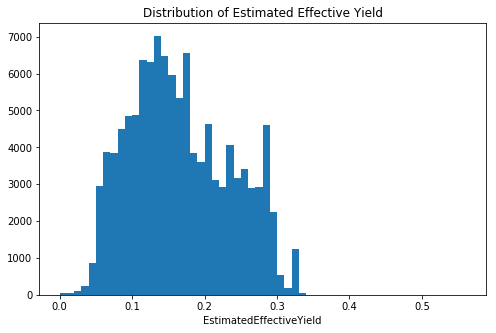

```python
plt.figure(figsize=[8,5])
base_color = sb.color_palette()[0]
bins = np.arange(0, df.BorrowerAPR.max()+0.05,0.01)
plt.hist(data=df, x='EstimatedEffectiveYield', bins = bins,color=base_color);
plt.xlabel('EstimatedEffectiveYield');
plt.title('Distribution of Estimated Effective Yield');
```

The distribution of Estimated Effective Yield is multimodial, with several peaks. Clearly very few to no loans have a effective yield past 0.35

## Prosper Score

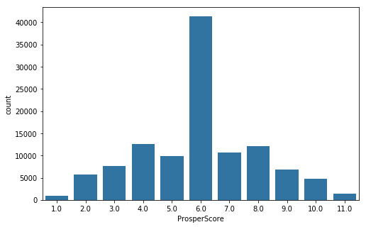

```python
plt.figure(figsize=[8,5])
base_color = sb.color_palette()[0]
sb.countplot(data=df, x='ProsperScore', color=base_color);
```

Most of the borrowers are scored at 6, with very few of the borrowers at the extreme ends of the scores, that is 1 and 11

## Loan status

> **Loan status** this is the current status of the loan

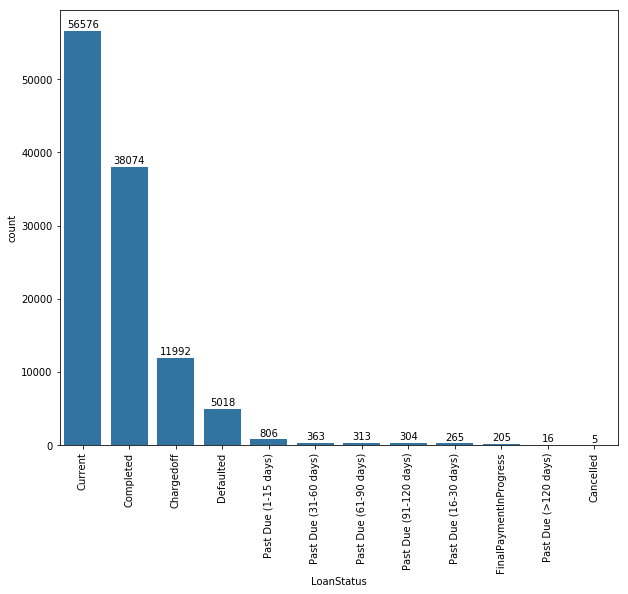

```python
plt.figure(figsize=[10,8])
freq = df['LoanStatus'].value_counts()
order = freq.index
sb.countplot(data = df, x = 'LoanStatus', color=base_color, order=order)
plt.xticks(rotation=90)
#Logic to print value on each bar
for i in range(freq.shape[0]):
    count = freq[i]

    plt.text(i, count+1500, count,ha='center',va='top')
```

## Monthly Loan Payment

> **Monthly Loan Payment** is the scheduled monthly loan payment

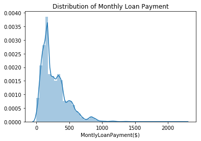

```python
sb.distplot(df['MonthlyLoanPayment']);
plt.xlabel('MontlyLoanPayment($)')
plt.title('Distribution of Monthly Loan Payment');
```

## Loan Original Amount

> **Loan Original Amount** - this is basically the original amount of loan the borrower borrows

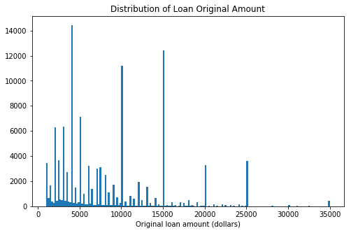

```python
max_amount = df.LoanOriginalAmount.max()
bins = np.arange(1000, max_amount+200, 200)
plt.figure(figsize=[8, 5])
plt.hist(data = df, x = 'LoanOriginalAmount', bins = bins);
plt.xlabel('Original loan amount (dollars)');
plt.title('Distribution of Loan Original Amount');
```

There are are large spikes around 5000,10000,15000,20000 and 25000. Which potrays that most people take loans of these amounts more compared to other amounts

## Term

> **Term** is the length of the loan expressed in months

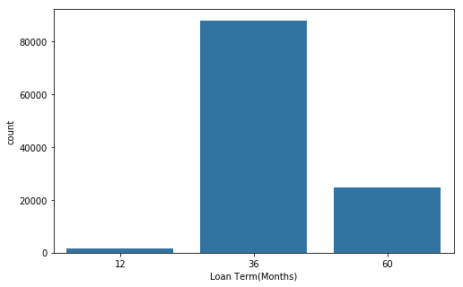

```python
plt.figure(figsize=[8,5])
base_color = sb.color_palette()[0]
sb.countplot(data=df, x='Term', color=base_color);
plt.xlabel('Loan Term(Months)');
```

Most of the people take Loans for 36 months as compared to other loan terms. Very few people take 12-months-term loans

### Discuss the distribution(s) of your variable(s) of interest. Were there any unusual points? Did you need to perform any transformations?

> The distribution of Estimated Effective Yield was multimodial with values mostly being between 0.05 and 0.3. There was no need to perform any transformations

### Of the features you investigated, were there any unusual distributions? Did you perform any operations on the data to tidy, adjust, or change the form of the data? If so, why did you do this?

> The monthly loan payment is rightly skewed with most of the people paying less than 500 dollars monthly.However, there are afew that pay more than 1000 dollars monthly but I'd consider them as outliers. There was no need to perform any operations on the data, I however created a new variable for the loan status that I will use later to create a predictive model.But I will not cover that in this submission

## Bivariate Exploration

> In this section, I investigate relationships between pairs of variables in my subset dataset.

### Scatter matrix plot

> I use this approach to compare multiple paired variables to check their correlation

```python
numeric_vars = ['EstimatedEffectiveYield','ProsperScore','Term','MonthlyLoanPayment','LoanOriginalAmount']
categoric_vars = ['LoanStatus','EmploymentStatus']
```

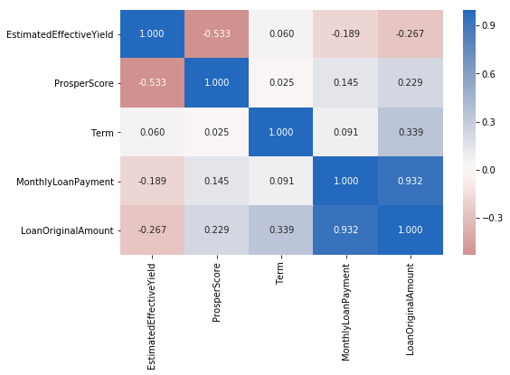

```python
# correlation plot
plt.figure(figsize = [8, 5])
sb.heatmap(df[numeric_vars].corr(), annot = True, fmt = '.3f',
           cmap = 'vlag_r', center = 0)
plt.show()
```

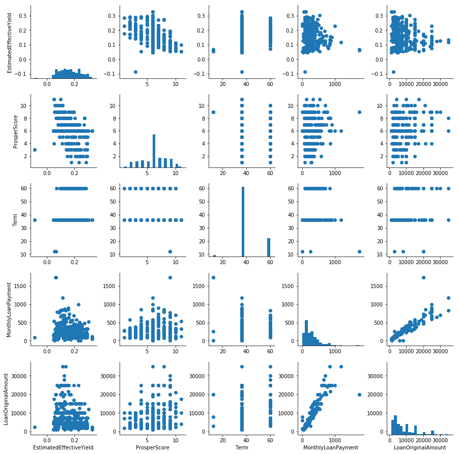

```python
df_sub = df.sample(n=300, replace=False)
g = sb.PairGrid(data = df_sub, vars=numeric_vars)
g = g.map_diag(plt.hist, bins=20)
g.map_offdiag(plt.scatter);
```

There is a positive correlation between Monthly loan payment and loan original amount, the correlation coefficient is 0.932. There is however a negative correlation between loan amount and effective yield, the correlation coefficient is -0.267

#### ProsperScore VS EstimatedEffectiveYield

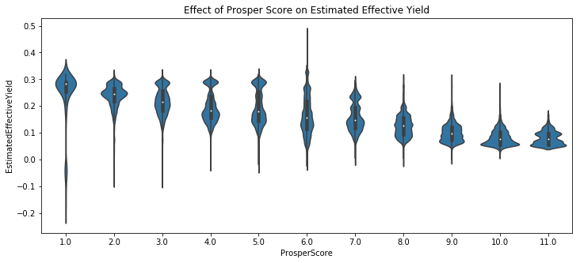

```python
plt.figure(figsize=[12,5])
base_color = sb.color_palette()[0]
sb.violinplot(data = df, y='EstimatedEffectiveYield',x='ProsperScore', color=base_color);
plt.title('Effect of Prosper Score on Estimated Effective Yield');
```

A higher Prosper score depicts a better borrower and a lower prosper score depicts a not-so-good borrower. From the plot we notice how the white dot, which is the median of estimated effective yield, drops as the Prosper score increases. This means lenders allow better interest rates to borrowers with higher rating. I best believe this acts as an incentive to keep them.

#### Estimated Effective Yield Vs Term

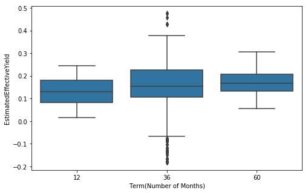

```python
plt.figure(figsize=[8,5])
base_color = sb.color_palette()[0]
sb.boxplot(data = df, y='EstimatedEffectiveYield',x='Term', color=base_color);
plt.xlabel('Term(Number of Months)');
```

As we can see the longer the term, the higher the interest rate, however the difference in increase is not as big, this is obviously encouraging for borrowers, since they would run away from big loans due to very high interest rates

#### Do bigger loans enjoy lesser interest rates(effective yield)?

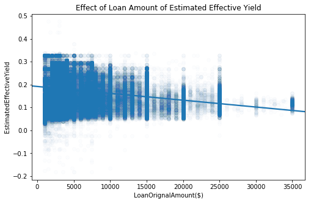

```python
plt.figure(figsize=[8,5])
sb.regplot(data = df, y='EstimatedEffectiveYield',x='LoanOriginalAmount', scatter_kws={'alpha':0.01});
plt.xlabel('LoanOrignalAmount($)')
plt.title('Effect of Loan Amount of Estimated Effective Yield');
```

The regplot shows that as the Loan amount increases, the Effective yield decreases, however it is important to note the difference is slight and not as drastic.

#### Does the length of the loan affect the original amount the borrower receives?

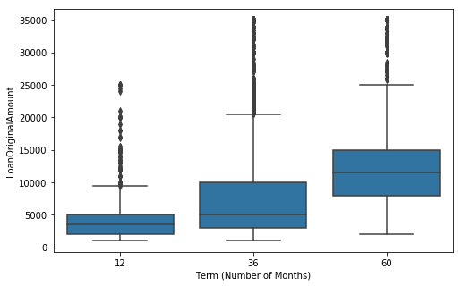

```python
plt.figure(figsize=[8,5])
base_color = sb.color_palette()[0]
sb.boxplot(data = df, y='LoanOriginalAmount',x='Term', color=base_color);
plt.xlabel('Term (Number of Months)');
```

As per my guess, the longer the Loan term, the higher the amount of loan the borrower is allowed to borrow. Which of course makes sense, since bigger loans will most likely need more time to pay them. However does it mean, the longer the term, the lower the interest rate. Lets quickly jump into that

#### How is Employment status and Prosper Score affect Loan Terms?

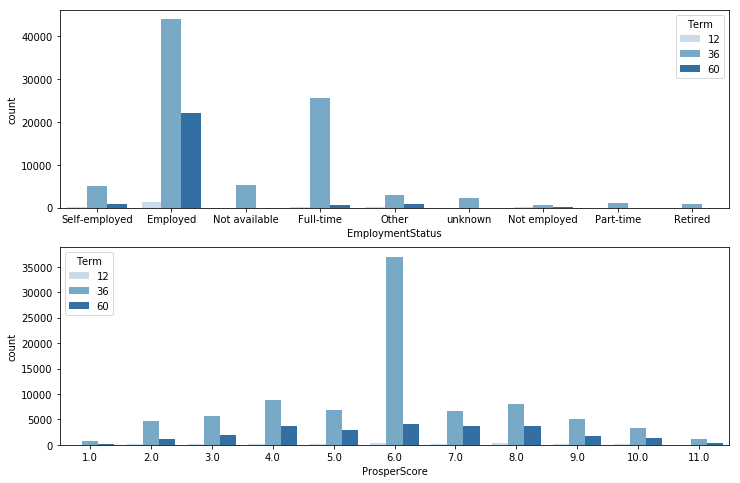

```python
plt.figure(figsize=[12,8])
plt.subplot(2,1,1)
sb.countplot(data = df, x = 'EmploymentStatus', hue = 'Term', palette = 'Blues')

plt.subplot(2,1,2)
sb.countplot(data = df, x = 'ProsperScore', hue = 'Term', palette = 'Blues');
```

It is clear that mostly the Employed and Fulltime category of borrowers borrow more and they mostly borrow loans with a duration of 36 months. The Employed category however has the highest 60 months loan-term loans.

Most of our borrowers as we had seen earlier are scored at 6 and most of them opt for the 36 months loan-term package over the other loan-term packages

#### What is the relationship between Loan Amount and Monthly Loan payment?

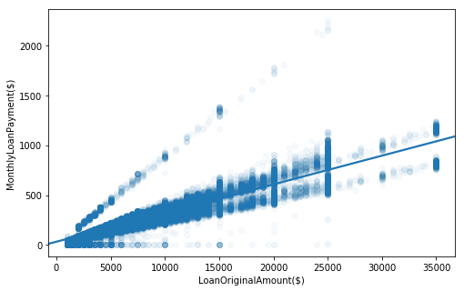

```python
plt.figure(figsize=[8,5])
sb.regplot(data = df, y='MonthlyLoanPayment',x='LoanOriginalAmount', scatter_kws={'alpha':0.03});
plt.xlabel('LoanOriginalAmount($)')
plt.ylabel('MonthlyLoanPayment($)');
```

There is a linear relationship between Loan original amount and monthly loan payment as seen above.

### Talk about some of the relationships you observed in this part of the investigation. How did the feature(s) of interest vary with other features in the dataset?

> The prosper score has a big impact on the effective yield, since better scores are granted the lesser effective yield amounts than poorer scores. I also noticed that as the Loan amount increases, the effective yield decreases, which is a good incentive for people to borrow bigger amounts.

### Did you observe any interesting relationships between the other features (not the main feature(s) of interest)?

> It was kinda obvious that bigger loan amounts come with longer loan terms. It was also evident that there is a positive correlation between Monthly loan payment and Loan Amount.

## Multivariate Exploration

> On this section I Create plots of three or more variables to investigate my dataset further

#### Prosper Score and Term effect on Original Loan Amount

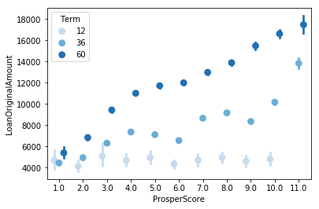

```python
sb.pointplot(data = df, x = 'ProsperScore', y = 'LoanOriginalAmount', hue = 'Term', palette = 'Blues',
             linestyles = '', dodge = 0.4);
```

It is clear that with better scores, Loan amounts increase and borrowers with bigger loan amounts tend to have longer loan terms. Therefore there is a correlation between these 3 features

#### Prosper Score and Term Effect on Estimated Effective yield

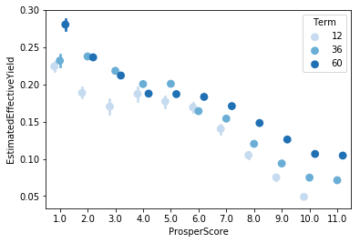

```python
sb.pointplot(data = df, x = 'ProsperScore', y = 'EstimatedEffectiveYield', hue = 'Term', palette = 'Blues',
             linestyles = '', dodge = 0.4);
```

#### Effect of Prosper Score on the relationship between loan amount and effective yield

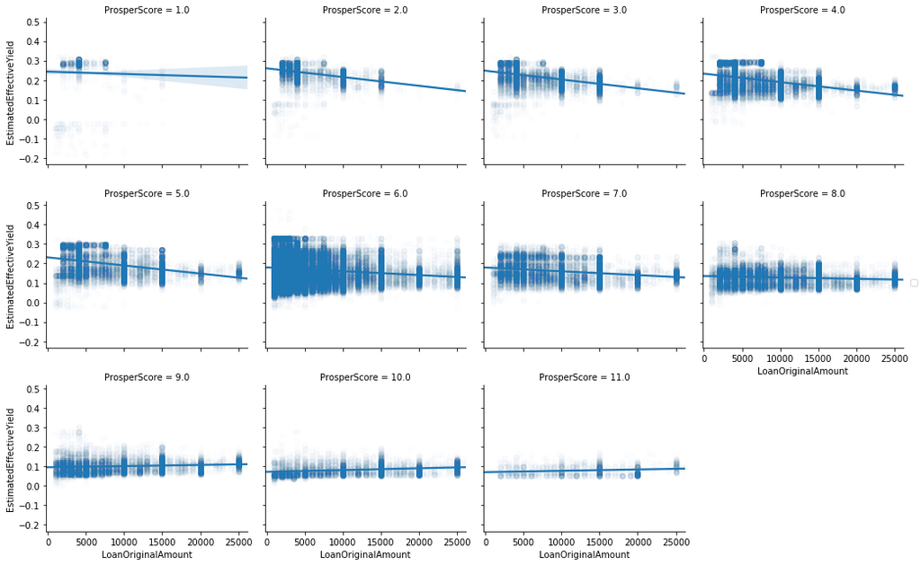

```python
g=sb.FacetGrid(data=df, aspect=1.2,col='ProsperScore', col_wrap=4)
g.map(sb.regplot, 'LoanOriginalAmount', 'EstimatedEffectiveYield', x_jitter=0.04, scatter_kws={'alpha':0.01});
g.add_legend();
```

It is clear that better prosper score decreases the effective yield but increases the Loan amount. Lesser score have higher effective yield and lesser loan amounts.

### Talk about some of the relationships you observed in this part of the investigation. Were there features that strengthened each other in terms of looking at your feature(s) of interest?

> I looked into the effect of Prosper score and term on effective yield. The exploration showed that better scores decrease the effective yield and increases the loan amount and vice versa

### Were there any interesting or surprising interactions between features?

> It was interesting that the relationship between effective yield and loan amount was negative as opposed to what I always believed, that is, bigger loans attract higher effective yields.